# Risk Factor Analysis

## Outcome Variable

**Outcome Variable:** whz

## Predictor Variables

**Intervention Variable:** mbmi

**Adjustment Set:**

unadjusted

## Stratifying Variables

The analysis was stratified on these variable(s):

- agecat
- studyid
- country

## Data Summary

| agecat | studyid | country | mbmi | n_cell | n |
| --- | --- | --- | --- | --- | --- |
| Birth | ki0047075b-MAL-ED | BANGLADESH | Normal weight | 183 | 209 |
| Birth | ki0047075b-MAL-ED | BANGLADESH | Underweight | 26 | 209 |
| Birth | ki0047075b-MAL-ED | BRAZIL | Normal weight | 56 | 61 |
| Birth | ki0047075b-MAL-ED | BRAZIL | Underweight | 5 | 61 |
| Birth | ki0047075b-MAL-ED | INDIA | Normal weight | 33 | 41 |
| Birth | ki0047075b-MAL-ED | INDIA | Underweight | 8 | 41 |
| Birth | ki0047075b-MAL-ED | NEPAL | Normal weight | 26 | 26 |
| Birth | ki0047075b-MAL-ED | NEPAL | Underweight | 0 | 26 |
| Birth | ki0047075b-MAL-ED | PERU | Normal weight | 216 | 221 |
| Birth | ki0047075b-MAL-ED | PERU | Underweight | 5 | 221 |
| Birth | ki0047075b-MAL-ED | SOUTH AFRICA | Normal weight | 97 | 100 |
| Birth | ki0047075b-MAL-ED | SOUTH AFRICA | Underweight | 3 | 100 |
| Birth | ki0047075b-MAL-ED | TANZANIA, UNITED REPUBLIC OF | Normal weight | 107 | 113 |
| Birth | ki0047075b-MAL-ED | TANZANIA, UNITED REPUBLIC OF | Underweight | 6 | 113 |
| Birth | ki1000304b-SAS-CompFeed | INDIA | Normal weight | 735 | 992 |
| Birth | ki1000304b-SAS-CompFeed | INDIA | Underweight | 257 | 992 |
| Birth | ki1017093-NIH-Birth | BANGLADESH | Normal weight | 483 | 575 |
| Birth | ki1017093-NIH-Birth | BANGLADESH | Underweight | 92 | 575 |
| Birth | ki1017093b-PROVIDE | BANGLADESH | Normal weight | 411 | 510 |
| Birth | ki1017093b-PROVIDE | BANGLADESH | Underweight | 99 | 510 |
| Birth | ki1017093c-NIH-Crypto | BANGLADESH | Normal weight | 639 | 704 |
| Birth | ki1017093c-NIH-Crypto | BANGLADESH | Underweight | 65 | 704 |
| Birth | ki1119695-PROBIT | BELARUS | Normal weight | 13143 | 13664 |
| Birth | ki1119695-PROBIT | BELARUS | Underweight | 521 | 13664 |
| Birth | ki1126311-ZVITAMBO | ZIMBABWE | Normal weight | 8574 | 9030 |
| Birth | ki1126311-ZVITAMBO | ZIMBABWE | Underweight | 456 | 9030 |
| Birth | kiGH5241-JiVitA-3 | BANGLADESH | Normal weight | 10934 | 17935 |
| Birth | kiGH5241-JiVitA-3 | BANGLADESH | Underweight | 7001 | 17935 |
| 6 months | ki0047075b-MAL-ED | BANGLADESH | Normal weight | 209 | 241 |
| 6 months | ki0047075b-MAL-ED | BANGLADESH | Underweight | 32 | 241 |

[output cut: 60 more lines]

The following strata were considered:

- agecat: 24 months, studyid: ki0047075b-MAL-ED, country: BANGLADESH
- agecat: 24 months, studyid: ki0047075b-MAL-ED, country: BRAZIL
- agecat: 24 months, studyid: ki0047075b-MAL-ED, country: INDIA
- agecat: 24 months, studyid: ki0047075b-MAL-ED, country: NEPAL
- agecat: 24 months, studyid: ki0047075b-MAL-ED, country: PERU
- agecat: 24 months, studyid: ki0047075b-MAL-ED, country: SOUTH AFRICA
- agecat: 24 months, studyid: ki0047075b-MAL-ED, country: TANZANIA, UNITED REPUBLIC OF
- agecat: 24 months, studyid: ki1017093-NIH-Birth, country: BANGLADESH
- agecat: 24 months, studyid: ki1017093b-PROVIDE, country: BANGLADESH
- agecat: 24 months, studyid: ki1017093c-NIH-Crypto, country: BANGLADESH
- agecat: 24 months, studyid: ki1066203-TanzaniaChild2, country: TANZANIA, UNITED REPUBLIC OF
- agecat: 24 months, studyid: ki1119695-PROBIT, country: BELARUS
- agecat: 24 months, studyid: ki1126311-ZVITAMBO, country: ZIMBABWE
- agecat: 24 months, studyid: ki1148112-LCNI-5, country: MALAWI
- agecat: 24 months, studyid: kiGH5241-JiVitA-3, country: BANGLADESH
- agecat: 6 months, studyid: ki0047075b-MAL-ED, country: BANGLADESH
- agecat: 6 months, studyid: ki0047075b-MAL-ED, country: BRAZIL
- agecat: 6 months, studyid: ki0047075b-MAL-ED, country: INDIA
- agecat: 6 months, studyid: ki0047075b-MAL-ED, country: NEPAL
- agecat: 6 months, studyid: ki0047075b-MAL-ED, country: PERU
- agecat: 6 months, studyid: ki0047075b-MAL-ED, country: SOUTH AFRICA
- agecat: 6 months, studyid: ki0047075b-MAL-ED, country: TANZANIA, UNITED REPUBLIC OF
- agecat: 6 months, studyid: ki1000304b-SAS-CompFeed, country: INDIA
- agecat: 6 months, studyid: ki1017093-NIH-Birth, country: BANGLADESH
- agecat: 6 months, studyid: ki1017093b-PROVIDE, country: BANGLADESH
- agecat: 6 months, studyid: ki1017093c-NIH-Crypto, country: BANGLADESH
- agecat: 6 months, studyid: ki1066203-TanzaniaChild2, country: TANZANIA, UNITED REPUBLIC OF
- agecat: 6 months, studyid: ki1119695-PROBIT, country: BELARUS
- agecat: 6 months, studyid: ki1126311-ZVITAMBO, country: ZIMBABWE
- agecat: 6 months, studyid: ki1148112-LCNI-5, country: MALAWI
- agecat: 6 months, studyid: kiGH5241-JiVitA-3, country: BANGLADESH
- agecat: Birth, studyid: ki0047075b-MAL-ED, country: BANGLADESH
- agecat: Birth, studyid: ki0047075b-MAL-ED, country: BRAZIL
- agecat: Birth, studyid: ki0047075b-MAL-ED, country: INDIA
- agecat: Birth, studyid: ki0047075b-MAL-ED, country: NEPAL
- agecat: Birth, studyid: ki0047075b-MAL-ED, country: PERU
- agecat: Birth, studyid: ki0047075b-MAL-ED, country: SOUTH AFRICA
- agecat: Birth, studyid: ki0047075b-MAL-ED, country: TANZANIA, UNITED REPUBLIC OF
- agecat: Birth, studyid: ki1000304b-SAS-CompFeed, country: INDIA
- agecat: Birth, studyid: ki1017093-NIH-Birth, country: BANGLADESH
- agecat: Birth, studyid: ki1017093b-PROVIDE, country: BANGLADESH
- agecat: Birth, studyid: ki1017093c-NIH-Crypto, country: BANGLADESH
- agecat: Birth, studyid: ki1119695-PROBIT, country: BELARUS
- agecat: Birth, studyid: ki1126311-ZVITAMBO, country: ZIMBABWE
- agecat: Birth, studyid: kiGH5241-JiVitA-3, country: BANGLADESH

### Dropped Strata

Some strata were dropped due to rare outcomes:

- agecat: Birth, studyid: ki0047075b-MAL-ED, country: NEPAL
- agecat: Birth, studyid: ki0047075b-MAL-ED, country: SOUTH AFRICA
- agecat: 6 months, studyid: ki0047075b-MAL-ED, country: NEPAL
- agecat: 24 months, studyid: ki0047075b-MAL-ED, country: NEPAL
- agecat: 24 months, studyid: ki0047075b-MAL-ED, country: PERU
- agecat: 24 months, studyid: ki1066203-TanzaniaChild2, country: TANZANIA, UNITED REPUBLIC OF

## Methods Detail

We’re interested in the causal parameters $E[Y_a]$ for all values of $a \in \mathcal{A}$. These parameters represent the mean outcome if, possibly contrary to fact, we intervened to set all units to have $A=a$. Under the randomization and positivity assumptions, these are identified by the statistical parameters $\psi_a=E_W[E_{Y|A,W}(Y|A=a,W)]$. In addition, we’re interested in the mean of $Y$, $E[Y]$ under no intervention (the observed mean). We will estimate these parameters by using SuperLearner to fit the relevant likelihood factors – $E_{Y|A,W}(Y|A=a,W)$ and $p(A=a|W)$, and then updating our likelihood fit using a joint TMLE.

For unadjusted analyses ($W=\{\}$), initial likelihoods were estimated using Lrnr_glm to estimate the simple $E(Y|A)$ and Lrnr_mean to estimate $p(A)$. For adjusted analyses, a small library containing Lrnr_glmnet, Lrnr_xgboost, and Lrnr_mean was used.

Having estimated these parameters, we will then use the delta method to estimate relative risks and attributable risks relative to a prespecified baseline level of $A$.

# Results Detail

## Results Plots

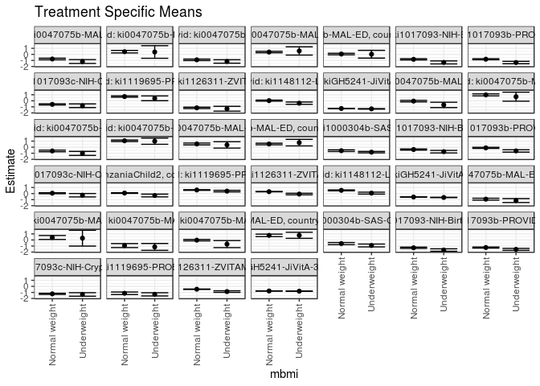

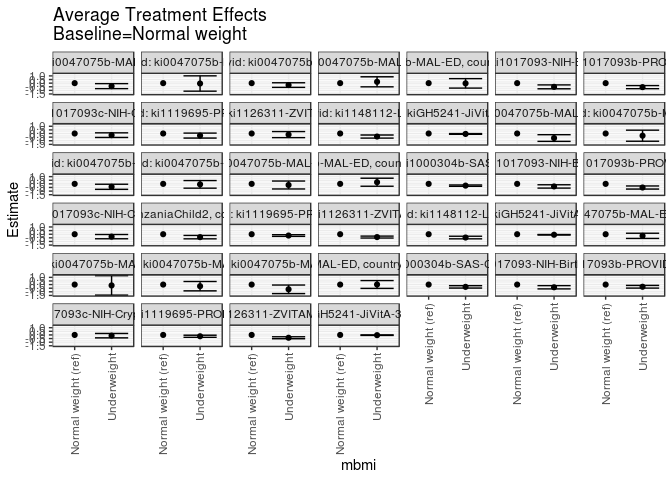

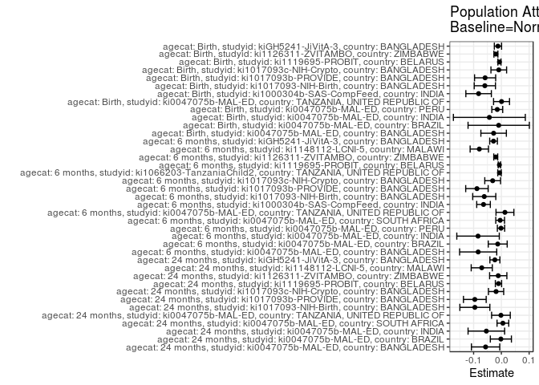

## Results Table

### Parameter: TSM

| agecat | studyid | country | intervention_level | baseline_level | estimate | ci_lower | ci_upper |
| --- | --- | --- | --- | --- | --- | --- | --- |
| Birth | ki0047075b-MAL-ED | BANGLADESH | Normal weight | NA | -0.9254645 | -1.0842545 | -0.7666745 |
| Birth | ki0047075b-MAL-ED | BANGLADESH | Underweight | NA | -1.1496154 | -1.4729446 | -0.8262862 |
| Birth | ki0047075b-MAL-ED | BRAZIL | Normal weight | NA | 0.4114286 | 0.0848121 | 0.7380451 |
| Birth | ki0047075b-MAL-ED | BRAZIL | Underweight | NA | 0.2940000 | -1.0086888 | 1.5966888 |
| Birth | ki0047075b-MAL-ED | INDIA | Normal weight | NA | -0.9245455 | -1.2487999 | -0.6002910 |
| Birth | ki0047075b-MAL-ED | INDIA | Underweight | NA | -1.1462500 | -1.7084286 | -0.5840714 |
| Birth | ki0047075b-MAL-ED | PERU | Normal weight | NA | -0.0281944 | -0.1526241 | 0.0962352 |
| Birth | ki0047075b-MAL-ED | PERU | Underweight | NA | -0.6820000 | -1.2614133 | -0.1025867 |
| Birth | ki0047075b-MAL-ED | TANZANIA, UNITED REPUBLIC OF | Normal weight | NA | 0.7576636 | 0.5539948 | 0.9613323 |
| Birth | ki0047075b-MAL-ED | TANZANIA, UNITED REPUBLIC OF | Underweight | NA | 0.7700000 | 0.2691531 | 1.2708469 |
| Birth | ki1000304b-SAS-CompFeed | INDIA | Normal weight | NA | -0.5932653 | -0.7699848 | -0.4165458 |
| Birth | ki1000304b-SAS-CompFeed | INDIA | Underweight | NA | -0.9096109 | -1.1425928 | -0.6766289 |
| Birth | ki1017093-NIH-Birth | BANGLADESH | Normal weight | NA | -1.2903830 | -1.3952122 | -1.1855538 |
| Birth | ki1017093-NIH-Birth | BANGLADESH | Underweight | NA | -1.6625000 | -1.8659492 | -1.4590508 |
| Birth | ki1017093b-PROVIDE | BANGLADESH | Normal weight | NA | -1.2475426 | -1.3349472 | -1.1601379 |
| Birth | ki1017093b-PROVIDE | BANGLADESH | Underweight | NA | -1.5491919 | -1.7161583 | -1.3822256 |
| Birth | ki1017093c-NIH-Crypto | BANGLADESH | Normal weight | NA | -1.2341236 | -1.3220079 | -1.1462394 |
| Birth | ki1017093c-NIH-Crypto | BANGLADESH | Underweight | NA | -1.3353846 | -1.6269297 | -1.0438395 |
| Birth | ki1119695-PROBIT | BELARUS | Normal weight | NA | -1.1359362 | -1.3459416 | -0.9259308 |
| Birth | ki1119695-PROBIT | BELARUS | Underweight | NA | -1.3192514 | -1.5844560 | -1.0540469 |
| Birth | ki1126311-ZVITAMBO | ZIMBABWE | Normal weight | NA | -0.4708642 | -0.5025987 | -0.4391298 |
| Birth | ki1126311-ZVITAMBO | ZIMBABWE | Underweight | NA | -0.8603728 | -0.9933594 | -0.7273862 |
| Birth | kiGH5241-JiVitA-3 | BANGLADESH | Normal weight | NA | -0.7658853 | -0.7892325 | -0.7425381 |
| Birth | kiGH5241-JiVitA-3 | BANGLADESH | Underweight | NA | -0.7973261 | -0.8248574 | -0.7697948 |
| 6 months | ki0047075b-MAL-ED | BANGLADESH | Normal weight | NA | -0.0541388 | -0.1825870 | 0.0743095 |
| 6 months | ki0047075b-MAL-ED | BANGLADESH | Underweight | NA | -0.6832812 | -1.1255393 | -0.2410232 |
| 6 months | ki0047075b-MAL-ED | BRAZIL | Normal weight | NA | 0.9779606 | 0.8096461 | 1.1462751 |
| 6 months | ki0047075b-MAL-ED | BRAZIL | Underweight | NA | 0.6750000 | -0.0698801 | 1.4198801 |
| 6 months | ki0047075b-MAL-ED | INDIA | Normal weight | NA | -0.6194176 | -0.7515606 | -0.4872746 |
| 6 months | ki0047075b-MAL-ED | INDIA | Underweight | NA | -1.0222619 | -1.3495967 | -0.6949271 |
| 6 months | ki0047075b-MAL-ED | PERU | Normal weight | NA | 1.0561298 | 0.9317231 | 1.1805366 |
| 6 months | ki0047075b-MAL-ED | PERU | Underweight | NA | 0.9870000 | 0.4781587 | 1.4958413 |
| 6 months | ki0047075b-MAL-ED | SOUTH AFRICA | Normal weight | NA | 0.5335468 | 0.3758513 | 0.6912424 |
| 6 months | ki0047075b-MAL-ED | SOUTH AFRICA | Underweight | NA | 0.3771429 | -0.1498294 | 0.9041151 |
| 6 months | ki0047075b-MAL-ED | TANZANIA, UNITED REPUBLIC OF | Normal weight | NA | 0.5233619 | 0.3882002 | 0.6585236 |
| 6 months | ki0047075b-MAL-ED | TANZANIA, UNITED REPUBLIC OF | Underweight | NA | 0.7502381 | 0.2105756 | 1.2899006 |
| 6 months | ki1000304b-SAS-CompFeed | INDIA | Normal weight | NA | -0.5783592 | -0.7169223 | -0.4397961 |
| 6 months | ki1000304b-SAS-CompFeed | INDIA | Underweight | NA | -0.8215586 | -0.9382729 | -0.7048444 |
| 6 months | ki1017093-NIH-Birth | BANGLADESH | Normal weight | NA | -0.3857676 | -0.4850715 | -0.2864638 |
| 6 months | ki1017093-NIH-Birth | BANGLADESH | Underweight | NA | -0.7416667 | -0.9501074 | -0.5332259 |
| 6 months | ki1017093b-PROVIDE | BANGLADESH | Normal weight | NA | -0.1107277 | -0.2003099 | -0.0211455 |
| 6 months | ki1017093b-PROVIDE | BANGLADESH | Underweight | NA | -0.6151429 | -0.8102973 | -0.4199884 |
| 6 months | ki1017093c-NIH-Crypto | BANGLADESH | Normal weight | NA | 0.0611188 | -0.0205751 | 0.1428127 |
| 6 months | ki1017093c-NIH-Crypto | BANGLADESH | Underweight | NA | -0.2735075 | -0.5552836 | 0.0082687 |
| 6 months | ki1066203-TanzaniaChild2 | TANZANIA, UNITED REPUBLIC OF | Normal weight | NA | 0.0842385 | 0.0298906 | 0.1385864 |
| 6 months | ki1066203-TanzaniaChild2 | TANZANIA, UNITED REPUBLIC OF | Underweight | NA | -0.3194444 | -0.5469897 | -0.0918991 |
| 6 months | ki1119695-PROBIT | BELARUS | Normal weight | NA | 0.5901098 | 0.5324492 | 0.6477705 |
| 6 months | ki1119695-PROBIT | BELARUS | Underweight | NA | 0.4066337 | 0.2758222 | 0.5374452 |
| 6 months | ki1126311-ZVITAMBO | ZIMBABWE | Normal weight | NA | 0.3150952 | 0.2869672 | 0.3432232 |
| 6 months | ki1126311-ZVITAMBO | ZIMBABWE | Underweight | NA | -0.0799597 | -0.2101186 | 0.0501992 |
| 6 months | ki1148112-LCNI-5 | MALAWI | Normal weight | NA | 0.5309841 | 0.4528265 | 0.6091417 |
| 6 months | ki1148112-LCNI-5 | MALAWI | Underweight | NA | 0.0730345 | -0.0870311 | 0.2331001 |
| 6 months | kiGH5241-JiVitA-3 | BANGLADESH | Normal weight | NA | -0.5649185 | -0.5879112 | -0.5419257 |
| 6 months | kiGH5241-JiVitA-3 | BANGLADESH | Underweight | NA | -0.6383981 | -0.6691543 | -0.6076419 |
| 24 months | ki0047075b-MAL-ED | BANGLADESH | Normal weight | NA | -0.7624863 | -0.8925038 | -0.6324688 |
| 24 months | ki0047075b-MAL-ED | BANGLADESH | Underweight | NA | -1.1777586 | -1.4973254 | -0.8581919 |
| 24 months | ki0047075b-MAL-ED | BRAZIL | Normal weight | NA | 0.4461317 | 0.2381826 | 0.6540808 |
| 24 months | ki0047075b-MAL-ED | BRAZIL | Underweight | NA | 0.3966667 | -0.6451983 | 1.4385316 |
| 24 months | ki0047075b-MAL-ED | INDIA | Normal weight | NA | -0.8978056 | -1.0217229 | -0.7738882 |
| 24 months | ki0047075b-MAL-ED | INDIA | Underweight | NA | -1.1636957 | -1.4544365 | -0.8729548 |
| 24 months | ki0047075b-MAL-ED | SOUTH AFRICA | Normal weight | NA | 0.3861417 | 0.2630585 | 0.5092249 |
| 24 months | ki0047075b-MAL-ED | SOUTH AFRICA | Underweight | NA | 0.5700000 | -0.1123856 | 1.2523856 |
| 24 months | ki0047075b-MAL-ED | TANZANIA, UNITED REPUBLIC OF | Normal weight | NA | 0.0563383 | -0.0709168 | 0.1835933 |
| 24 months | ki0047075b-MAL-ED | TANZANIA, UNITED REPUBLIC OF | Underweight | NA | 0.0263636 | -0.6148109 | 0.6675382 |
| 24 months | ki1017093-NIH-Birth | BANGLADESH | Normal weight | NA | -0.8161207 | -0.9193416 | -0.7128997 |
| 24 months | ki1017093-NIH-Birth | BANGLADESH | Underweight | NA | -1.3268229 | -1.5771056 | -1.0765402 |
| 24 months | ki1017093b-PROVIDE | BANGLADESH | Normal weight | NA | -0.7958054 | -0.8847238 | -0.7068871 |
| 24 months | ki1017093b-PROVIDE | BANGLADESH | Underweight | NA | -1.3485500 | -1.5444018 | -1.1526982 |
| 24 months | ki1017093c-NIH-Crypto | BANGLADESH | Normal weight | NA | -0.5912739 | -0.6905730 | -0.4919748 |
| 24 months | ki1017093c-NIH-Crypto | BANGLADESH | Underweight | NA | -0.8193023 | -1.1245646 | -0.5140400 |
| 24 months | ki1119695-PROBIT | BELARUS | Normal weight | NA | 0.6984228 | 0.5886954 | 0.8081502 |
| 24 months | ki1119695-PROBIT | BELARUS | Underweight | NA | 0.4089716 | 0.0184295 | 0.7995138 |
| 24 months | ki1126311-ZVITAMBO | ZIMBABWE | Normal weight | NA | -1.1605900 | -1.2738933 | -1.0472866 |
| 24 months | ki1126311-ZVITAMBO | ZIMBABWE | Underweight | NA | -1.3133333 | -1.7153552 | -0.9113114 |
| 24 months | ki1148112-LCNI-5 | MALAWI | Normal weight | NA | 0.0237580 | -0.0655402 | 0.1130563 |
| 24 months | ki1148112-LCNI-5 | MALAWI | Underweight | NA | -0.3977660 | -0.5912901 | -0.2042418 |
| 24 months | kiGH5241-JiVitA-3 | BANGLADESH | Normal weight | NA | -1.2736969 | -1.3032409 | -1.2441529 |
| 24 months | kiGH5241-JiVitA-3 | BANGLADESH | Underweight | NA | -1.3344178 | -1.3712853 | -1.2975504 |

### Parameter: E(Y)

| agecat | studyid | country | intervention_level | baseline_level | estimate | ci_lower | ci_upper |
| --- | --- | --- | --- | --- | --- | --- | --- |
| Birth | ki0047075b-MAL-ED | BANGLADESH | NA | NA | -0.9533493 | -1.0984355 | -0.8082631 |
| Birth | ki0047075b-MAL-ED | BRAZIL | NA | NA | 0.4018033 | 0.0834093 | 0.7201973 |
| Birth | ki0047075b-MAL-ED | INDIA | NA | NA | -0.9678049 | -1.2522118 | -0.6833979 |
| Birth | ki0047075b-MAL-ED | PERU | NA | NA | -0.0429864 | -0.1658406 | 0.0798678 |
| Birth | ki0047075b-MAL-ED | TANZANIA, UNITED REPUBLIC OF | NA | NA | 0.7583186 | 0.5636385 | 0.9529987 |
| Birth | ki1000304b-SAS-CompFeed | INDIA | NA | NA | -0.6752218 | -0.8548888 | -0.4955547 |
| Birth | ki1017093-NIH-Birth | BANGLADESH | NA | NA | -1.3499217 | -1.4444634 | -1.2553801 |
| Birth | ki1017093b-PROVIDE | BANGLADESH | NA | NA | -1.3060980 | -1.3843247 | -1.2278714 |
| Birth | ki1017093c-NIH-Crypto | BANGLADESH | NA | NA | -1.2434730 | -1.3276901 | -1.1592559 |
| Birth | ki1119695-PROBIT | BELARUS | NA | NA | -1.1429259 | -1.3532676 | -0.9325843 |
| Birth | ki1126311-ZVITAMBO | ZIMBABWE | NA | NA | -0.4905338 | -0.5214551 | -0.4596125 |
| Birth | kiGH5241-JiVitA-3 | BANGLADESH | NA | NA | -0.7781583 | -0.7971779 | -0.7591388 |
| 6 months | ki0047075b-MAL-ED | BANGLADESH | NA | NA | -0.1376763 | -0.2664642 | -0.0088885 |
| 6 months | ki0047075b-MAL-ED | BRAZIL | NA | NA | 0.9648518 | 0.8004118 | 1.1292917 |
| 6 months | ki0047075b-MAL-ED | INDIA | NA | NA | -0.7034149 | -0.8300527 | -0.5767771 |
| 6 months | ki0047075b-MAL-ED | PERU | NA | NA | 1.0548591 | 0.9328922 | 1.1768259 |
| 6 months | ki0047075b-MAL-ED | SOUTH AFRICA | NA | NA | 0.5291499 | 0.3751396 | 0.6831602 |
| 6 months | ki0047075b-MAL-ED | TANZANIA, UNITED REPUBLIC OF | NA | NA | 0.5362213 | 0.4049390 | 0.6675036 |
| 6 months | ki1000304b-SAS-CompFeed | INDIA | NA | NA | -0.6426305 | -0.7702214 | -0.5150396 |
| 6 months | ki1017093-NIH-Birth | BANGLADESH | NA | NA | -0.4474038 | -0.5378167 | -0.3569909 |
| 6 months | ki1017093b-PROVIDE | BANGLADESH | NA | NA | -0.1987071 | -0.2815473 | -0.1158669 |
| 6 months | ki1017093c-NIH-Crypto | BANGLADESH | NA | NA | 0.0297622 | -0.0491685 | 0.1086930 |
| 6 months | ki1066203-TanzaniaChild2 | TANZANIA, UNITED REPUBLIC OF | NA | NA | 0.0775172 | 0.0241750 | 0.1308595 |
| 6 months | ki1119695-PROBIT | BELARUS | NA | NA | 0.5829956 | 0.5247249 | 0.6412663 |
| 6 months | ki1126311-ZVITAMBO | ZIMBABWE | NA | NA | 0.2948332 | 0.2672524 | 0.3224139 |
| 6 months | ki1148112-LCNI-5 | MALAWI | NA | NA | 0.4515550 | 0.3802638 | 0.5228463 |
| 6 months | kiGH5241-JiVitA-3 | BANGLADESH | NA | NA | -0.5931545 | -0.6127055 | -0.5736036 |
| 24 months | ki0047075b-MAL-ED | BANGLADESH | NA | NA | -0.8192925 | -0.9412667 | -0.6973182 |
| 24 months | ki0047075b-MAL-ED | BRAZIL | NA | NA | 0.4443651 | 0.2404149 | 0.6483153 |
| 24 months | ki0047075b-MAL-ED | INDIA | NA | NA | -0.9519248 | -1.0678488 | -0.8360007 |
| 24 months | ki0047075b-MAL-ED | SOUTH AFRICA | NA | NA | 0.3916417 | 0.2704414 | 0.5128421 |
| 24 months | ki0047075b-MAL-ED | TANZANIA, UNITED REPUBLIC OF | NA | NA | 0.0547975 | -0.0703378 | 0.1799328 |
| 24 months | ki1017093-NIH-Birth | BANGLADESH | NA | NA | -0.9115790 | -1.0095022 | -0.8136559 |
| 24 months | ki1017093b-PROVIDE | BANGLADESH | NA | NA | -0.8914360 | -0.9741797 | -0.8086923 |
| 24 months | ki1017093c-NIH-Crypto | BANGLADESH | NA | NA | -0.6103502 | -0.7050157 | -0.5156847 |
| 24 months | ki1119695-PROBIT | BELARUS | NA | NA | 0.6880695 | 0.5737062 | 0.8024328 |
| 24 months | ki1126311-ZVITAMBO | ZIMBABWE | NA | NA | -1.1718579 | -1.2809898 | -1.0627260 |
| 24 months | ki1148112-LCNI-5 | MALAWI | NA | NA | -0.0468717 | -0.1290135 | 0.0352701 |
| 24 months | kiGH5241-JiVitA-3 | BANGLADESH | NA | NA | -1.2970642 | -1.3203662 | -1.2737621 |

### Parameter: ATE

| agecat | studyid | country | intervention_level | baseline_level | estimate | ci_lower | ci_upper |
| --- | --- | --- | --- | --- | --- | --- | --- |
| Birth | ki0047075b-MAL-ED | BANGLADESH | Normal weight | Normal weight | 0.0000000 | 0.0000000 | 0.0000000 |
| Birth | ki0047075b-MAL-ED | BANGLADESH | Underweight | Normal weight | -0.2241509 | -0.5843675 | 0.1360657 |
| Birth | ki0047075b-MAL-ED | BRAZIL | Normal weight | Normal weight | 0.0000000 | 0.0000000 | 0.0000000 |
| Birth | ki0047075b-MAL-ED | BRAZIL | Underweight | Normal weight | -0.1174286 | -1.4604388 | 1.2255816 |
| Birth | ki0047075b-MAL-ED | INDIA | Normal weight | Normal weight | 0.0000000 | 0.0000000 | 0.0000000 |
| Birth | ki0047075b-MAL-ED | INDIA | Underweight | Normal weight | -0.2217045 | -0.8706928 | 0.4272837 |
| Birth | ki0047075b-MAL-ED | PERU | Normal weight | Normal weight | 0.0000000 | 0.0000000 | 0.0000000 |
| Birth | ki0047075b-MAL-ED | PERU | Underweight | Normal weight | -0.6538056 | -1.2464290 | -0.0611821 |
| Birth | ki0047075b-MAL-ED | TANZANIA, UNITED REPUBLIC OF | Normal weight | Normal weight | 0.0000000 | 0.0000000 | 0.0000000 |
| Birth | ki0047075b-MAL-ED | TANZANIA, UNITED REPUBLIC OF | Underweight | Normal weight | 0.0123364 | -0.5283378 | 0.5530107 |
| Birth | ki1000304b-SAS-CompFeed | INDIA | Normal weight | Normal weight | 0.0000000 | 0.0000000 | 0.0000000 |
| Birth | ki1000304b-SAS-CompFeed | INDIA | Underweight | Normal weight | -0.3163456 | -0.4835789 | -0.1491122 |
| Birth | ki1017093-NIH-Birth | BANGLADESH | Normal weight | Normal weight | 0.0000000 | 0.0000000 | 0.0000000 |
| Birth | ki1017093-NIH-Birth | BANGLADESH | Underweight | Normal weight | -0.3721170 | -0.6009854 | -0.1432486 |
| Birth | ki1017093b-PROVIDE | BANGLADESH | Normal weight | Normal weight | 0.0000000 | 0.0000000 | 0.0000000 |
| Birth | ki1017093b-PROVIDE | BANGLADESH | Underweight | Normal weight | -0.3016493 | -0.4901098 | -0.1131889 |
| Birth | ki1017093c-NIH-Crypto | BANGLADESH | Normal weight | Normal weight | 0.0000000 | 0.0000000 | 0.0000000 |
| Birth | ki1017093c-NIH-Crypto | BANGLADESH | Underweight | Normal weight | -0.1012610 | -0.4057641 | 0.2032422 |
| Birth | ki1119695-PROBIT | BELARUS | Normal weight | Normal weight | 0.0000000 | 0.0000000 | 0.0000000 |
| Birth | ki1119695-PROBIT | BELARUS | Underweight | Normal weight | -0.1833152 | -0.3300967 | -0.0365337 |
| Birth | ki1126311-ZVITAMBO | ZIMBABWE | Normal weight | Normal weight | 0.0000000 | 0.0000000 | 0.0000000 |
| Birth | ki1126311-ZVITAMBO | ZIMBABWE | Underweight | Normal weight | -0.3895086 | -0.5262291 | -0.2527880 |
| Birth | kiGH5241-JiVitA-3 | BANGLADESH | Normal weight | Normal weight | 0.0000000 | 0.0000000 | 0.0000000 |
| Birth | kiGH5241-JiVitA-3 | BANGLADESH | Underweight | Normal weight | -0.0314408 | -0.0648574 | 0.0019759 |
| 6 months | ki0047075b-MAL-ED | BANGLADESH | Normal weight | Normal weight | 0.0000000 | 0.0000000 | 0.0000000 |
| 6 months | ki0047075b-MAL-ED | BANGLADESH | Underweight | Normal weight | -0.6291425 | -1.0896760 | -0.1686090 |
| 6 months | ki0047075b-MAL-ED | BRAZIL | Normal weight | Normal weight | 0.0000000 | 0.0000000 | 0.0000000 |
| 6 months | ki0047075b-MAL-ED | BRAZIL | Underweight | Normal weight | -0.3029606 | -1.0666204 | 0.4606991 |
| 6 months | ki0047075b-MAL-ED | INDIA | Normal weight | Normal weight | 0.0000000 | 0.0000000 | 0.0000000 |
| 6 months | ki0047075b-MAL-ED | INDIA | Underweight | Normal weight | -0.4028443 | -0.7558456 | -0.0498431 |
| 6 months | ki0047075b-MAL-ED | PERU | Normal weight | Normal weight | 0.0000000 | 0.0000000 | 0.0000000 |
| 6 months | ki0047075b-MAL-ED | PERU | Underweight | Normal weight | -0.0691298 | -0.5929586 | 0.4546989 |
| 6 months | ki0047075b-MAL-ED | SOUTH AFRICA | Normal weight | Normal weight | 0.0000000 | 0.0000000 | 0.0000000 |
| 6 months | ki0047075b-MAL-ED | SOUTH AFRICA | Underweight | Normal weight | -0.1564040 | -0.7064654 | 0.3936575 |
| 6 months | ki0047075b-MAL-ED | TANZANIA, UNITED REPUBLIC OF | Normal weight | Normal weight | 0.0000000 | 0.0000000 | 0.0000000 |
| 6 months | ki0047075b-MAL-ED | TANZANIA, UNITED REPUBLIC OF | Underweight | Normal weight | 0.2268761 | -0.3294549 | 0.7832072 |
| 6 months | ki1000304b-SAS-CompFeed | INDIA | Normal weight | Normal weight | 0.0000000 | 0.0000000 | 0.0000000 |
| 6 months | ki1000304b-SAS-CompFeed | INDIA | Underweight | Normal weight | -0.2431994 | -0.3322064 | -0.1541925 |
| 6 months | ki1017093-NIH-Birth | BANGLADESH | Normal weight | Normal weight | 0.0000000 | 0.0000000 | 0.0000000 |
| 6 months | ki1017093-NIH-Birth | BANGLADESH | Underweight | Normal weight | -0.3558990 | -0.5867860 | -0.1250120 |
| 6 months | ki1017093b-PROVIDE | BANGLADESH | Normal weight | Normal weight | 0.0000000 | 0.0000000 | 0.0000000 |
| 6 months | ki1017093b-PROVIDE | BANGLADESH | Underweight | Normal weight | -0.5044152 | -0.7191481 | -0.2896823 |
| 6 months | ki1017093c-NIH-Crypto | BANGLADESH | Normal weight | Normal weight | 0.0000000 | 0.0000000 | 0.0000000 |
| 6 months | ki1017093c-NIH-Crypto | BANGLADESH | Underweight | Normal weight | -0.3346263 | -0.6280061 | -0.0412465 |
| 6 months | ki1066203-TanzaniaChild2 | TANZANIA, UNITED REPUBLIC OF | Normal weight | Normal weight | 0.0000000 | 0.0000000 | 0.0000000 |
| 6 months | ki1066203-TanzaniaChild2 | TANZANIA, UNITED REPUBLIC OF | Underweight | Normal weight | -0.4036829 | -0.6376286 | -0.1697373 |
| 6 months | ki1119695-PROBIT | BELARUS | Normal weight | Normal weight | 0.0000000 | 0.0000000 | 0.0000000 |
| 6 months | ki1119695-PROBIT | BELARUS | Underweight | Normal weight | -0.1834762 | -0.2974540 | -0.0694983 |
| 6 months | ki1126311-ZVITAMBO | ZIMBABWE | Normal weight | Normal weight | 0.0000000 | 0.0000000 | 0.0000000 |
| 6 months | ki1126311-ZVITAMBO | ZIMBABWE | Underweight | Normal weight | -0.3950549 | -0.5282184 | -0.2618913 |
| 6 months | ki1148112-LCNI-5 | MALAWI | Normal weight | Normal weight | 0.0000000 | 0.0000000 | 0.0000000 |
| 6 months | ki1148112-LCNI-5 | MALAWI | Underweight | Normal weight | -0.4579496 | -0.6360777 | -0.2798215 |
| 6 months | kiGH5241-JiVitA-3 | BANGLADESH | Normal weight | Normal weight | 0.0000000 | 0.0000000 | 0.0000000 |
| 6 months | kiGH5241-JiVitA-3 | BANGLADESH | Underweight | Normal weight | -0.0734797 | -0.1094961 | -0.0374632 |
| 24 months | ki0047075b-MAL-ED | BANGLADESH | Normal weight | Normal weight | 0.0000000 | 0.0000000 | 0.0000000 |
| 24 months | ki0047075b-MAL-ED | BANGLADESH | Underweight | Normal weight | -0.4152723 | -0.7602759 | -0.0702687 |
| 24 months | ki0047075b-MAL-ED | BRAZIL | Normal weight | Normal weight | 0.0000000 | 0.0000000 | 0.0000000 |
| 24 months | ki0047075b-MAL-ED | BRAZIL | Underweight | Normal weight | -0.0494650 | -1.1118799 | 1.0129498 |
| 24 months | ki0047075b-MAL-ED | INDIA | Normal weight | Normal weight | 0.0000000 | 0.0000000 | 0.0000000 |
| 24 months | ki0047075b-MAL-ED | INDIA | Underweight | Normal weight | -0.2658901 | -0.5819372 | 0.0501570 |
| 24 months | ki0047075b-MAL-ED | SOUTH AFRICA | Normal weight | Normal weight | 0.0000000 | 0.0000000 | 0.0000000 |
| 24 months | ki0047075b-MAL-ED | SOUTH AFRICA | Underweight | Normal weight | 0.1838583 | -0.5095388 | 0.8772554 |
| 24 months | ki0047075b-MAL-ED | TANZANIA, UNITED REPUBLIC OF | Normal weight | Normal weight | 0.0000000 | 0.0000000 | 0.0000000 |
| 24 months | ki0047075b-MAL-ED | TANZANIA, UNITED REPUBLIC OF | Underweight | Normal weight | -0.0299746 | -0.6836555 | 0.6237062 |
| 24 months | ki1017093-NIH-Birth | BANGLADESH | Normal weight | Normal weight | 0.0000000 | 0.0000000 | 0.0000000 |
| 24 months | ki1017093-NIH-Birth | BANGLADESH | Underweight | Normal weight | -0.5107022 | -0.7814346 | -0.2399699 |
| 24 months | ki1017093b-PROVIDE | BANGLADESH | Normal weight | Normal weight | 0.0000000 | 0.0000000 | 0.0000000 |
| 24 months | ki1017093b-PROVIDE | BANGLADESH | Underweight | Normal weight | -0.5527446 | -0.7678362 | -0.3376530 |
| 24 months | ki1017093c-NIH-Crypto | BANGLADESH | Normal weight | Normal weight | 0.0000000 | 0.0000000 | 0.0000000 |
| 24 months | ki1017093c-NIH-Crypto | BANGLADESH | Underweight | Normal weight | -0.2280284 | -0.5490353 | 0.0929784 |
| 24 months | ki1119695-PROBIT | BELARUS | Normal weight | Normal weight | 0.0000000 | 0.0000000 | 0.0000000 |
| 24 months | ki1119695-PROBIT | BELARUS | Underweight | Normal weight | -0.2894512 | -0.6317924 | 0.0528901 |
| 24 months | ki1126311-ZVITAMBO | ZIMBABWE | Normal weight | Normal weight | 0.0000000 | 0.0000000 | 0.0000000 |
| 24 months | ki1126311-ZVITAMBO | ZIMBABWE | Underweight | Normal weight | -0.1527434 | -0.5704266 | 0.2649399 |
| 24 months | ki1148112-LCNI-5 | MALAWI | Normal weight | Normal weight | 0.0000000 | 0.0000000 | 0.0000000 |
| 24 months | ki1148112-LCNI-5 | MALAWI | Underweight | Normal weight | -0.4215240 | -0.6346573 | -0.2083907 |
| 24 months | kiGH5241-JiVitA-3 | BANGLADESH | Normal weight | Normal weight | 0.0000000 | 0.0000000 | 0.0000000 |
| 24 months | kiGH5241-JiVitA-3 | BANGLADESH | Underweight | Normal weight | -0.0607209 | -0.1074865 | -0.0139554 |

### Parameter: PAR

| agecat | studyid | country | intervention_level | baseline_level | estimate | ci_lower | ci_upper |
| --- | --- | --- | --- | --- | --- | --- | --- |
| Birth | ki0047075b-MAL-ED | BANGLADESH | Normal weight | NA | -0.0278848 | -0.0738104 | 0.0180408 |
| Birth | ki0047075b-MAL-ED | BRAZIL | Normal weight | NA | -0.0096253 | -0.1200094 | 0.1007588 |
| Birth | ki0047075b-MAL-ED | INDIA | Normal weight | NA | -0.0432594 | -0.1727854 | 0.0862665 |
| Birth | ki0047075b-MAL-ED | PERU | Normal weight | NA | -0.0147920 | -0.0344019 | 0.0048180 |
| Birth | ki0047075b-MAL-ED | TANZANIA, UNITED REPUBLIC OF | Normal weight | NA | 0.0006550 | -0.0280579 | 0.0293680 |
| Birth | ki1000304b-SAS-CompFeed | INDIA | Normal weight | NA | -0.0819565 | -0.1279013 | -0.0360116 |
| Birth | ki1017093-NIH-Birth | BANGLADESH | Normal weight | NA | -0.0595387 | -0.0978205 | -0.0212569 |
| Birth | ki1017093b-PROVIDE | BANGLADESH | Normal weight | NA | -0.0585555 | -0.0965789 | -0.0205320 |
| Birth | ki1017093c-NIH-Crypto | BANGLADESH | Normal weight | NA | -0.0093494 | -0.0375474 | 0.0188486 |
| Birth | ki1119695-PROBIT | BELARUS | Normal weight | NA | -0.0069897 | -0.0125913 | -0.0013881 |
| Birth | ki1126311-ZVITAMBO | ZIMBABWE | Normal weight | NA | -0.0196695 | -0.0267943 | -0.0125448 |
| Birth | kiGH5241-JiVitA-3 | BANGLADESH | Normal weight | NA | -0.0122730 | -0.0253242 | 0.0007781 |
| 6 months | ki0047075b-MAL-ED | BANGLADESH | Normal weight | NA | -0.0835376 | -0.1503868 | -0.0166884 |
| 6 months | ki0047075b-MAL-ED | BRAZIL | Normal weight | NA | -0.0131089 | -0.0472021 | 0.0209844 |
| 6 months | ki0047075b-MAL-ED | INDIA | Normal weight | NA | -0.0839973 | -0.1605303 | -0.0074644 |
| 6 months | ki0047075b-MAL-ED | PERU | Normal weight | NA | -0.0012708 | -0.0144131 | 0.0118715 |
| 6 months | ki0047075b-MAL-ED | SOUTH AFRICA | Normal weight | NA | -0.0043969 | -0.0201917 | 0.0113979 |
| 6 months | ki0047075b-MAL-ED | TANZANIA, UNITED REPUBLIC OF | Normal weight | NA | 0.0128594 | -0.0193478 | 0.0450666 |
| 6 months | ki1000304b-SAS-CompFeed | INDIA | Normal weight | NA | -0.0642713 | -0.0887730 | -0.0397697 |
| 6 months | ki1017093-NIH-Birth | BANGLADESH | Normal weight | NA | -0.0616361 | -0.1032158 | -0.0200565 |
| 6 months | ki1017093b-PROVIDE | BANGLADESH | Normal weight | NA | -0.0879794 | -0.1284385 | -0.0475203 |
| 6 months | ki1017093c-NIH-Crypto | BANGLADESH | Normal weight | NA | -0.0313566 | -0.0597634 | -0.0029498 |
| 6 months | ki1066203-TanzaniaChild2 | TANZANIA, UNITED REPUBLIC OF | Normal weight | NA | -0.0067213 | -0.0129966 | -0.0004459 |
| 6 months | ki1119695-PROBIT | BELARUS | Normal weight | NA | -0.0071142 | -0.0114363 | -0.0027922 |
| 6 months | ki1126311-ZVITAMBO | ZIMBABWE | Normal weight | NA | -0.0202620 | -0.0273803 | -0.0131438 |
| 6 months | ki1148112-LCNI-5 | MALAWI | Normal weight | NA | -0.0794291 | -0.1124873 | -0.0463708 |
| 6 months | kiGH5241-JiVitA-3 | BANGLADESH | Normal weight | NA | -0.0282361 | -0.0420734 | -0.0143987 |
| 24 months | ki0047075b-MAL-ED | BANGLADESH | Normal weight | NA | -0.0568061 | -0.1077766 | -0.0058356 |
| 24 months | ki0047075b-MAL-ED | BRAZIL | Normal weight | NA | -0.0017666 | -0.0397355 | 0.0362023 |
| 24 months | ki0047075b-MAL-ED | INDIA | Normal weight | NA | -0.0541192 | -0.1199507 | 0.0117123 |
| 24 months | ki0047075b-MAL-ED | SOUTH AFRICA | Normal weight | NA | 0.0055000 | -0.0156289 | 0.0266289 |
| 24 months | ki0047075b-MAL-ED | TANZANIA, UNITED REPUBLIC OF | Normal weight | NA | -0.0015408 | -0.0351529 | 0.0320714 |
| 24 months | ki1017093-NIH-Birth | BANGLADESH | Normal weight | NA | -0.0954584 | -0.1494712 | -0.0414455 |
| 24 months | ki1017093b-PROVIDE | BANGLADESH | Normal weight | NA | -0.0956305 | -0.1365676 | -0.0546935 |
| 24 months | ki1017093c-NIH-Crypto | BANGLADESH | Normal weight | NA | -0.0190763 | -0.0464811 | 0.0083285 |
| 24 months | ki1119695-PROBIT | BELARUS | Normal weight | NA | -0.0103533 | -0.0216411 | 0.0009346 |
| 24 months | ki1126311-ZVITAMBO | ZIMBABWE | Normal weight | NA | -0.0112680 | -0.0423517 | 0.0198158 |
| 24 months | ki1148112-LCNI-5 | MALAWI | Normal weight | NA | -0.0706297 | -0.1086477 | -0.0326117 |
| 24 months | kiGH5241-JiVitA-3 | BANGLADESH | Normal weight | NA | -0.0233673 | -0.0413593 | -0.0053753 |